# IADLs - Doing housework

# 1 Description of DataSchema variable

The description of harmonised variable is the following:

- Short name: `iadl_housewk`
- Variable label: `IADL - Difficulties for doing housework`
- Domain: `Health status and functional limitations`
- Value type: `categorical`
- Category coding:

| **Code** | **Category Label** |
| --- | --- |
| 0 | Yes |
| 1 | No |

- Category missings:

| **Code** | **Category Label** |
| --- | --- |
| 991 | CAPI/interviewer error |
| 992 | Impute |
| 993 | Disable to measure |
| 994 | Not attempt/not done |
| 995 | Does not answer |
| 996 | Not applicable |
| 997 | Refuse |
| 998 | Do not know |
| 999 | Missing |

# 2 Data process

## 2.1 England

### 2.1.1 Wave 1

#### 2.1.1.1 Study-specific variable description

- Name: `headlho`
- Label: `IADL: Difficulty doing work around house and garden`
- Categories:
  - `0 = Not mentioned`
  - `1 = Mentioned`
- Missings
  - `-9 = Refusal`
  - `-8 = Don't know`
  - `-1 = Not applicable`

| Sample size | Missing values |
| --- | --- |
| 12099 | 0 |

Category

|  | -9 | -8 | -1 | 0 | 1 |
| --- | --- | --- | --- | --- | --- |
| Frequency | 4.00 | 12.0 | 175.00 | 10029.00 | 1879.00 |
| Percentage | 0.03 | 0.1 | 1.45 | 82.89 | 15.53 |

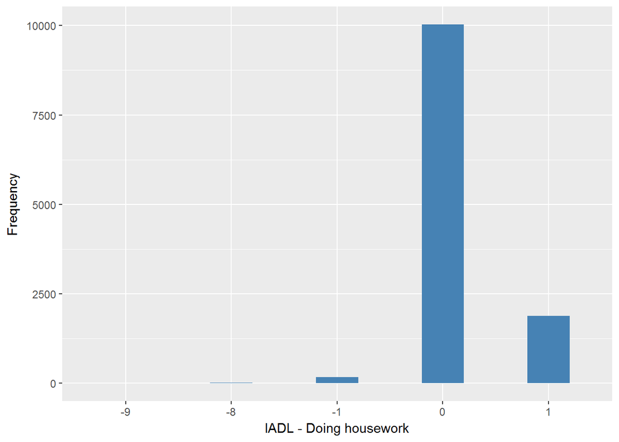

#### 2.1.1.2 Harmonisation algorithm

To compute the harmonize variable from the study-specific variable it has to be recoded as follows:

- `1 into 0`
- `0 into 1`
- `-9 Refusal into 997`
- `-8 Don't know into 998`
- `-1 Not applicable into 996`

**R script:**

```r
ELSA_ds_w1 <- tibble(id = ELSA_w1_iadl_housewk$id)
ELSA_ds_w1$iadl_housewk <- car::recode(ELSA_w1_iadl_housewk$headlho, "0 = '1';1 = '0';-9 = '997';-8 = '998';-1 = '996' ")
ELSA_ds_w1$iadl_housewk <- labelled(ELSA_ds_w1$iadl_housewk, labels = c(Yes = 0,
    No = 1, Missing = 999, Do_not_know = 998, Refuse = 997, Not_applicable = 996,
    Does_not_answer = 995, Not_attempt_not_done = 994, Disable_to_measure = 993,
    Impute = 992, CAPI_interviewer_error = 991))
```

#### 2.1.1.3 Statistical description of the new harmonised variable

| Sample size | Missing values |
| --- | --- |
| 12099 | 191 |

Category

|  | 0 | 1 |
| --- | --- | --- |
| Frequency | 1879.00 | 10029.00 |
| Percentage | 15.53 | 82.89 |

Type of missing

|  | 991 | 992 | 993 | 994 | 995 | 996 | 997 | 998 | 999 | NA |
| --- | --- | --- | --- | --- | --- | --- | --- | --- | --- | --- |
| Frequency | 0 | 0 | 0 | 0 | 0 | 175.00 | 4.00 | 12.0 | 0 | 0 |
| Percentage | 0 | 0 | 0 | 0 | 0 | 1.45 | 0.03 | 0.1 | 0 | 0 |

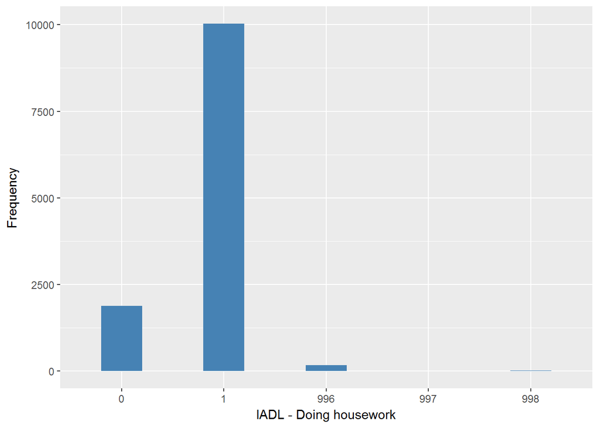

#### 2.1.1.4 Validation

|  | 1->0 | 0->1 | -1->996 | -9->997 | -8->998 |
| --- | --- | --- | --- | --- | --- |
| BeforeH | 1879 | 10029 | 175 | 4 | 12 |
| AfterH | 1879 | 10029 | 175 | 4 | 12 |

### 2.1.2 Wave 2

#### 2.1.2.1 Study-specific variable description

- Name: `headlho`
- Label: `IADL: Difficulty doing work around house and garden`
- Categories:
  - `0 = Not mentioned`
  - `1 = Mentioned`
- Missings
  - `-9 = Refusal`
  - `-8 = Don't know`

| Sample size | Missing values |
| --- | --- |
| 9432 | 0 |

Category

|  | -9 | -8 | 0 | 1 |
| --- | --- | --- | --- | --- |
| Frequency | 2.00 | 1.00 | 7834.00 | 1595.00 |
| Percentage | 0.02 | 0.01 | 83.06 | 16.91 |

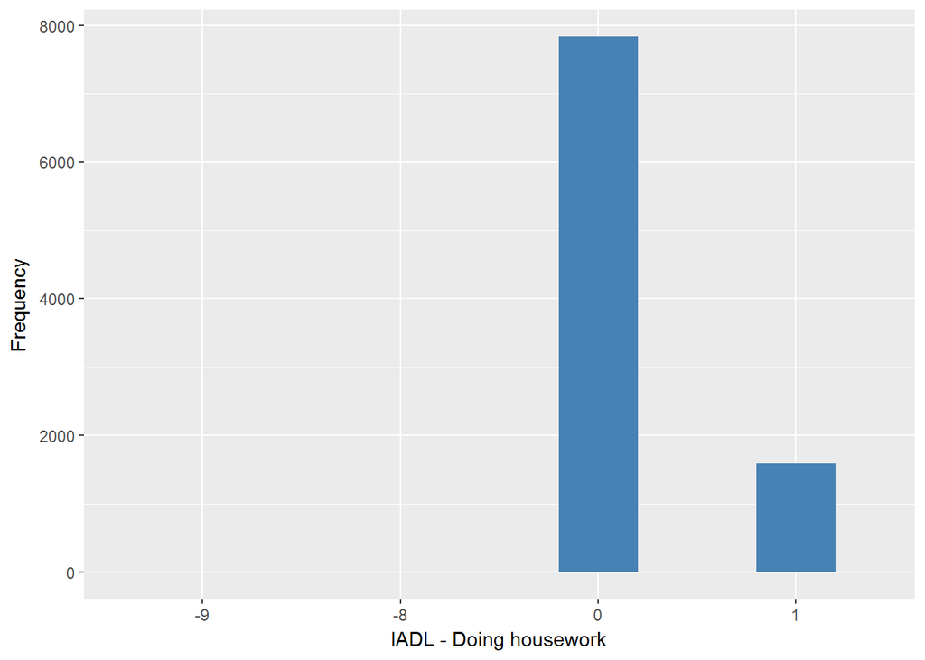

#### 2.1.2.2 Harmonisation algorithm

To compute the harmonize variable from the study-specific variable it has to be recoded as follows:

- `1 into 0`
- `0 into 1`
- `-9 Refusal into 997`
- `-8 Don't know into 998`

**R script:**

```r
ELSA_ds_w2 <- tibble(id = ELSA_w2_iadl_housewk$id)
ELSA_ds_w2$iadl_housewk <- car::recode(ELSA_w2_iadl_housewk$headlho, "0 = '1';1 = '0';-9 = '997';-8 = '998';-1 = '996' ")
ELSA_ds_w2$iadl_housewk <- labelled(ELSA_ds_w2$iadl_housewk, labels = c(Yes = 0,
    No = 1, Missing = 999, Do_not_know = 998, Refuse = 997, Not_applicable = 996,
    Does_not_answer = 995, Not_attempt_not_done = 994, Disable_to_measure = 993,
    Impute = 992, CAPI_interviewer_error = 991))
```

#### 2.1.2.3 Statistical description of the new harmonised variable

| Sample size | Missing values |
| --- | --- |
| 9432 | 3 |

Category

|  | 0 | 1 |
| --- | --- | --- |
| Frequency | 1595.00 | 7834.00 |
| Percentage | 16.91 | 83.06 |

Type of missing

|  | 991 | 992 | 993 | 994 | 995 | 996 | 997 | 998 | 999 | NA |
| --- | --- | --- | --- | --- | --- | --- | --- | --- | --- | --- |
| Frequency | 0 | 0 | 0 | 0 | 0 | 0 | 2.00 | 1.00 | 0 | 0 |
| Percentage | 0 | 0 | 0 | 0 | 0 | 0 | 0.02 | 0.01 | 0 | 0 |

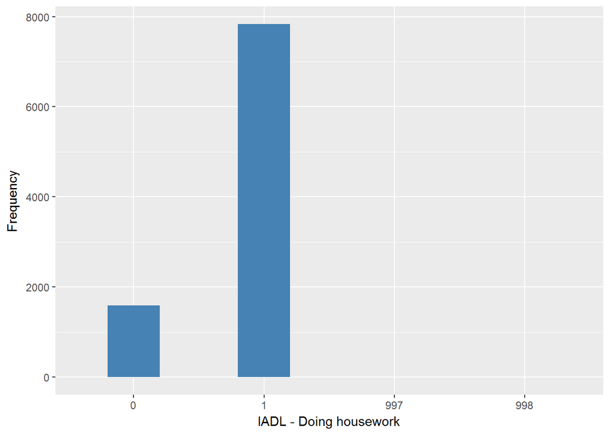

#### 2.1.2.4 Validation

|  | 1->0 | 0->1 | -9->997 | -8->998 |
| --- | --- | --- | --- | --- |
| BeforeH | 1595 | 7834 | 2 | 1 |
| AfterH | 1595 | 7834 | 2 | 1 |

### 2.1.3 Wave 3

#### 2.1.3.1 Study-specific variable description

- Name: `headlho`
- Label: `IADL: Difficulty doing work around house and garden`
- Categories:
  - `0 = Not mentioned`
  - `1 = Mentioned`
- Missings
  - `-1 = Not applicable`

HEADLHO

| Sample size | Missing values |
| --- | --- |
| 9771 | 0 |

Category

|  | -1 | 0 | 1 |
| --- | --- | --- | --- |
| Frequency | 4.00 | 8292.00 | 1475.0 |
| Percentage | 0.04 | 84.86 | 15.1 |

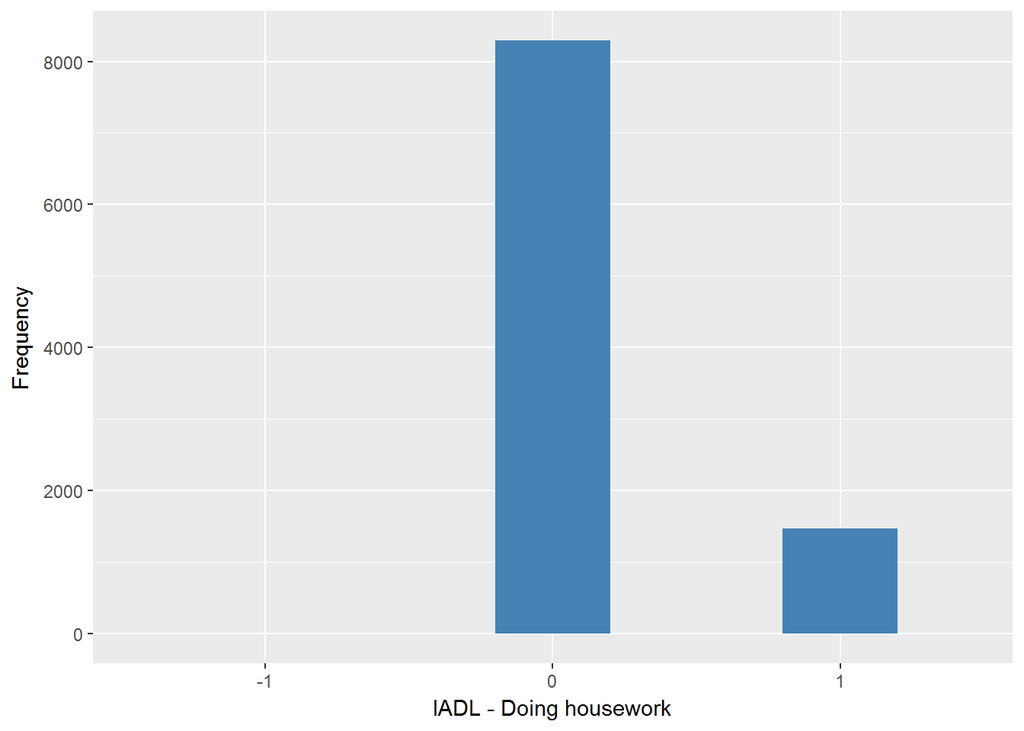

#### 2.1.3.2 Harmonisation algorithm

To compute the harmonize variable from the study-specific variable it has to be recoded as follows:

- `1 into 0`
- `0 into 1`
- `-1 Not applicable into 996`

**R script:**

```r
ELSA_ds_w3 <- tibble(id = ELSA_w3_iadl_housewk$id)
ELSA_ds_w3$iadl_housewk <- car::recode(ELSA_w3_iadl_housewk$headlho, "0 = '1';1 = '0';-9 = '997';-8 = '998';-1 = '996' ")
ELSA_ds_w3$iadl_housewk <- labelled(ELSA_ds_w3$iadl_housewk, labels = c(Yes = 0,
    No = 1, Missing = 999, Do_not_know = 998, Refuse = 997, Not_applicable = 996,
    Does_not_answer = 995, Not_attempt_not_done = 994, Disable_to_measure = 993,
    Impute = 992, CAPI_interviewer_error = 991))
```

#### 2.1.3.3 Statistical description of the new harmonised variable

| Sample size | Missing values |
| --- | --- |
| 9771 | 4 |

Category

|  | 0 | 1 |
| --- | --- | --- |
| Frequency | 1475.0 | 8292.00 |
| Percentage | 15.1 | 84.86 |

Type of missing

|  | 991 | 992 | 993 | 994 | 995 | 996 | 997 | 998 | 999 | NA |
| --- | --- | --- | --- | --- | --- | --- | --- | --- | --- | --- |
| Frequency | 0 | 0 | 0 | 0 | 0 | 4.00 | 0 | 0 | 0 | 0 |
| Percentage | 0 | 0 | 0 | 0 | 0 | 0.04 | 0 | 0 | 0 | 0 |

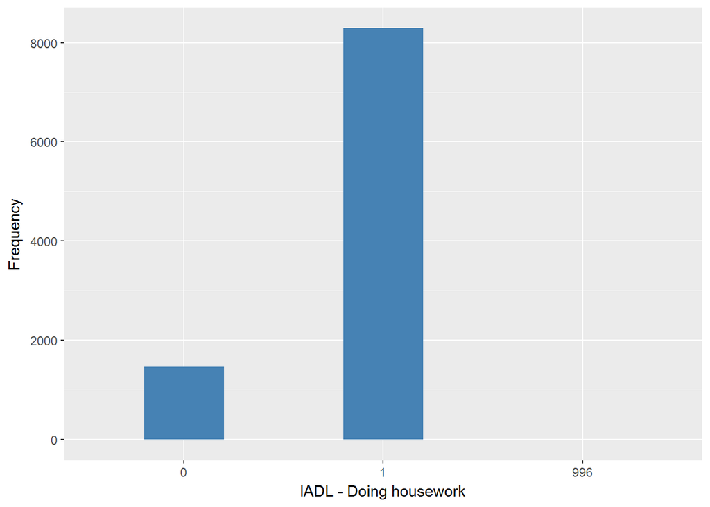

#### 2.1.3.4 Validation

|  | 1->0 | 0->1 | -1->996 |
| --- | --- | --- | --- |
| BeforeH | 1475 | 8292 | 4 |
| AfterH | 1475 | 8292 | 4 |

### 2.1.4 Wave 4

#### 2.1.4.1 Study-specific variable description

- Name: `headlho`
- Label: `IADL: Difficulty doing work around house and garden`
- Categories:
  - `0 = Not mentioned`
  - `1 = Mentioned`
- Missings
  - `-9 = Refusal`
  - `-8 = Don't know`

| Sample size | Missing values |
| --- | --- |
| 11050 | 0 |

Category

|  | -9 | -8 | 0 | 1 |
| --- | --- | --- | --- | --- |
| Frequency | 7.00 | 2.00 | 9431.00 | 1610.00 |
| Percentage | 0.06 | 0.02 | 85.35 | 14.57 |

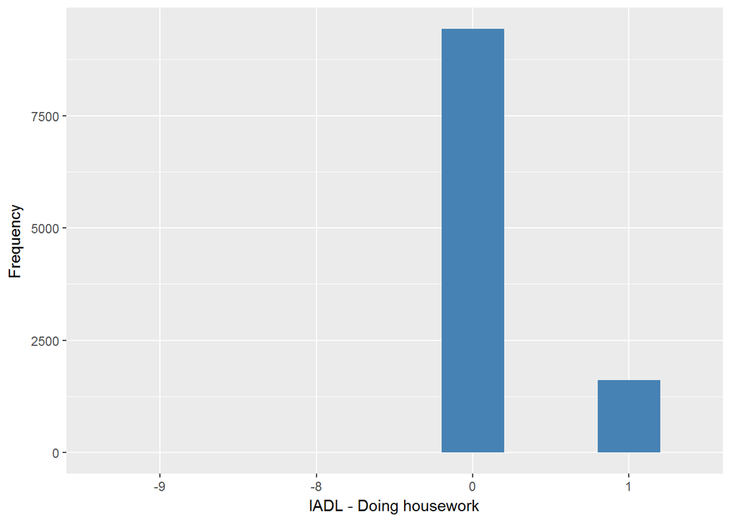

#### 2.1.4.2 Harmonisation algorithm

To compute the harmonize variable from the study-specific variable it has to be recoded as follows:

- `1 into 0`
- `0 into 1`
- `-9 Refusal into 997`
- `-8 Don't know into 998`

**R script:**

```r
ELSA_ds_w4 <- tibble(id = ELSA_w4_iadl_housewk$id)
ELSA_ds_w4$iadl_housewk <- car::recode(ELSA_w4_iadl_housewk$headlho, "0 = '1';1 = '0';-9 = '997';-8 = '998';-1 = '996' ")
ELSA_ds_w4$iadl_housewk <- labelled(ELSA_ds_w4$iadl_housewk, labels = c(Yes = 0,
    No = 1, Missing = 999, Do_not_know = 998, Refuse = 997, Not_applicable = 996,
    Does_not_answer = 995, Not_attempt_not_done = 994, Disable_to_measure = 993,
    Impute = 992, CAPI_interviewer_error = 991))
```

#### 2.1.4.3 Statistical description of the new harmonised variable

| Sample size | Missing values |
| --- | --- |
| 11050 | 9 |

Category

|  | 0 | 1 |
| --- | --- | --- |
| Frequency | 1610.00 | 9431.00 |
| Percentage | 14.57 | 85.35 |

Type of missing

|  | 991 | 992 | 993 | 994 | 995 | 996 | 997 | 998 | 999 | NA |
| --- | --- | --- | --- | --- | --- | --- | --- | --- | --- | --- |
| Frequency | 0 | 0 | 0 | 0 | 0 | 0 | 7.00 | 2.00 | 0 | 0 |
| Percentage | 0 | 0 | 0 | 0 | 0 | 0 | 0.06 | 0.02 | 0 | 0 |

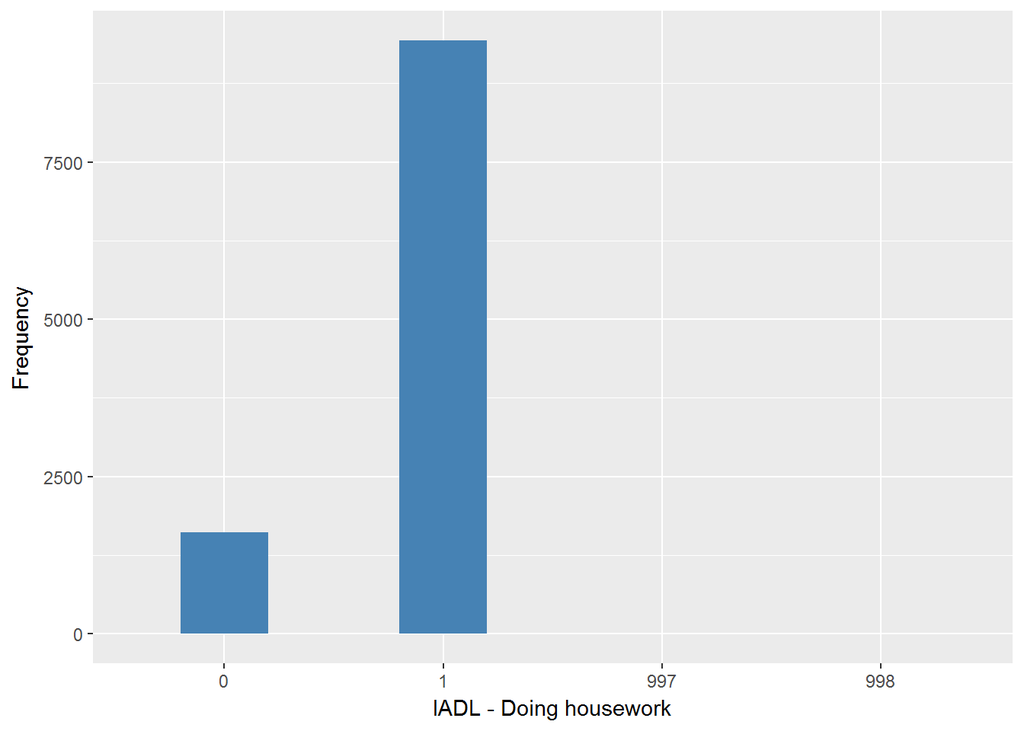

#### 2.1.4.4 Validation

|  | 1->0 | 0->1 | -9->997 | -8->998 |
| --- | --- | --- | --- | --- |
| BeforeH | 1610 | 9431 | 7 | 2 |
| AfterH | 1610 | 9431 | 7 | 2 |

### 2.1.5 Wave 5

#### 2.1.5.1 Study-specific variable description

- Name: `headlho`
- Label: `IADL: Difficulty doing work around house and garden`
- Categories:
  - `0 = Not mentioned`
  - `1 = Mentioned`
- Missings
  - `-9 = Refusal`
  - `-8 = Don't know`

| Sample size | Missing values |
| --- | --- |
| 10274 | 0 |

Category

|  | -9 | -8 | 0 | 1 |
| --- | --- | --- | --- | --- |
| Frequency | 5.00 | 3.00 | 8659.00 | 1607.00 |
| Percentage | 0.05 | 0.03 | 84.28 | 15.64 |

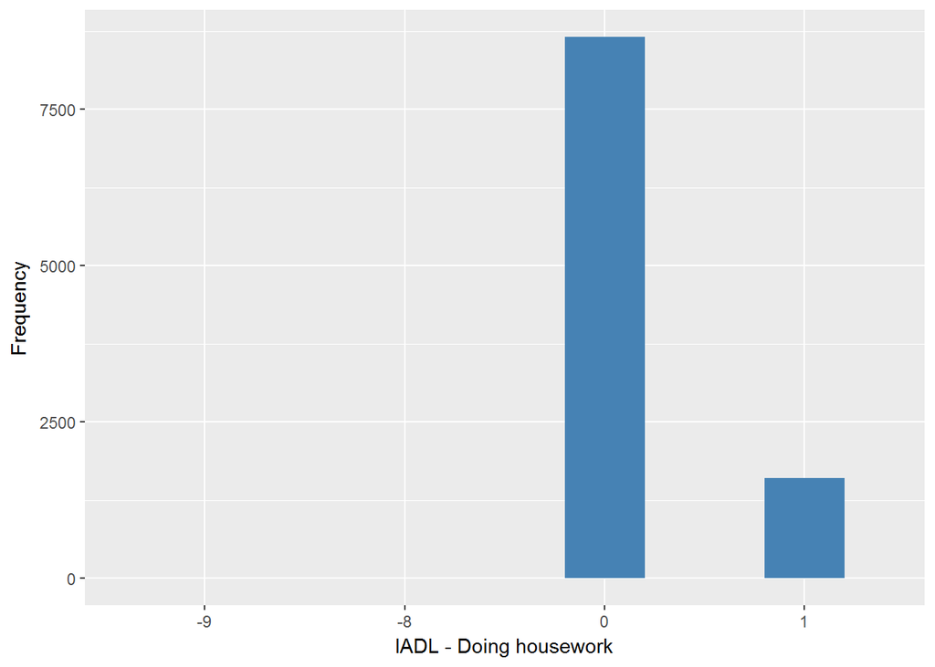

#### 2.1.5.2 Harmonisation algorithm

To compute the harmonize variable from the study-specific variable it has to be recoded as follows:

- `1 into 0`
- `0 into 1`
- `-9 Refusal into 997`
- `-8 Don't know into 998`

**R script:**

```r
ELSA_ds_w5 <- tibble(id = ELSA_w5_iadl_housewk$id)
ELSA_ds_w5$iadl_housewk <- car::recode(ELSA_w5_iadl_housewk$headlho, "0 = '1';1 = '0';-9 = '997';-8 = '998';-1 = '996' ")
ELSA_ds_w5$iadl_housewk <- labelled(ELSA_ds_w5$iadl_housewk, labels = c(Yes = 0,
    No = 1, Missing = 999, Do_not_know = 998, Refuse = 997, Not_applicable = 996,
    Does_not_answer = 995, Not_attempt_not_done = 994, Disable_to_measure = 993,
    Impute = 992, CAPI_interviewer_error = 991))
```

#### 2.1.5.3 Statistical description of the new harmonised variable

| Sample size | Missing values |
| --- | --- |
| 10274 | 8 |

Category

|  | 0 | 1 |
| --- | --- | --- |
| Frequency | 1607.00 | 8659.00 |
| Percentage | 15.64 | 84.28 |

Type of missing

|  | 991 | 992 | 993 | 994 | 995 | 996 | 997 | 998 | 999 | NA |
| --- | --- | --- | --- | --- | --- | --- | --- | --- | --- | --- |
| Frequency | 0 | 0 | 0 | 0 | 0 | 0 | 5.00 | 3.00 | 0 | 0 |
| Percentage | 0 | 0 | 0 | 0 | 0 | 0 | 0.05 | 0.03 | 0 | 0 |

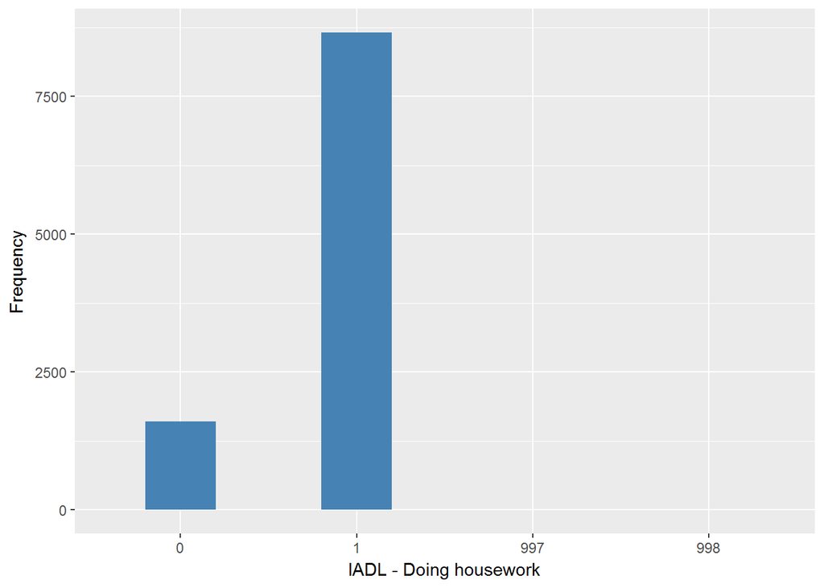

#### 2.1.5.4 Validation

|  | 1->0 | 0->1 | -9->997 | -8->998 |
| --- | --- | --- | --- | --- |
| BeforeH | 1607 | 8659 | 5 | 3 |
| AfterH | 1607 | 8659 | 5 | 3 |

### 2.1.6 Wave 6

#### 2.1.6.1 Study-specific variable description

- Name: `headlho`
- Label: `IADL: Difficulty doing work around house and garden`
- Categories:
  - `0 = Not mentioned`
  - `1 = Mentioned`
- Missings
  - `-9 = Refusal`
  - `-8 = Don't know`

HEADLHO

| Sample size | Missing values |
| --- | --- |
| 10601 | 0 |

Category

|  | -9 | -8 | 0 | 1 |
| --- | --- | --- | --- | --- |
| Frequency | 3.00 | 2.00 | 8991.00 | 1605.00 |
| Percentage | 0.03 | 0.02 | 84.81 | 15.14 |

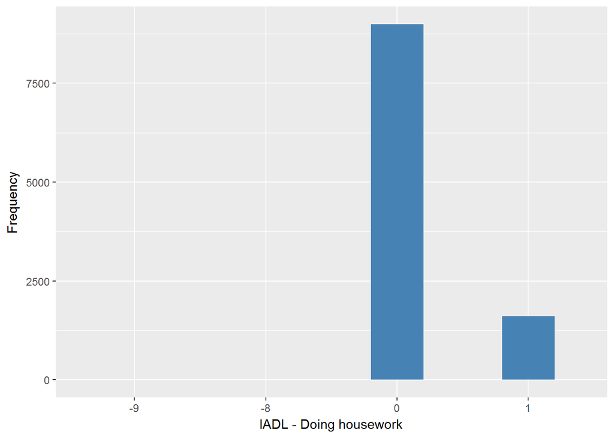

#### 2.1.6.2 Harmonisation algorithm

To compute the harmonize variable from the study-specific variable it has to be recoded as follows:

- `1 into 0`
- `0 into 1`
- `-9 Refusal into 997`
- `-8 Don't know into 998`

**R script:**

```r
ELSA_ds_w6 <- tibble(id = ELSA_w6_iadl_housewk$id)
ELSA_ds_w6$iadl_housewk <- car::recode(ELSA_w6_iadl_housewk$headlho, "0 = '1';1 = '0';-9 = '997';-8 = '998';-1 = '996' ")
ELSA_ds_w6$iadl_housewk <- labelled(ELSA_ds_w6$iadl_housewk, labels = c(Yes = 0,
    No = 1, Missing = 999, Do_not_know = 998, Refuse = 997, Not_applicable = 996,
    Does_not_answer = 995, Not_attempt_not_done = 994, Disable_to_measure = 993,
    Impute = 992, CAPI_interviewer_error = 991))
```

#### 2.1.6.3 Statistical description of the new harmonised variable

| Sample size | Missing values |
| --- | --- |
| 10601 | 5 |

Category

|  | 0 | 1 |
| --- | --- | --- |
| Frequency | 1605.00 | 8991.00 |
| Percentage | 15.14 | 84.81 |

Type of missing

|  | 991 | 992 | 993 | 994 | 995 | 996 | 997 | 998 | 999 | NA |
| --- | --- | --- | --- | --- | --- | --- | --- | --- | --- | --- |
| Frequency | 0 | 0 | 0 | 0 | 0 | 0 | 3.00 | 2.00 | 0 | 0 |
| Percentage | 0 | 0 | 0 | 0 | 0 | 0 | 0.03 | 0.02 | 0 | 0 |

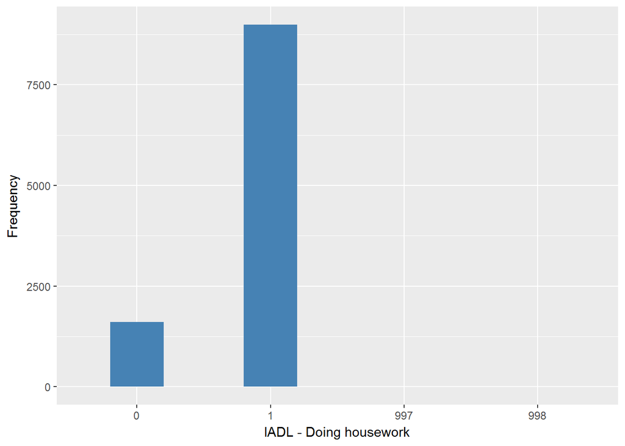

#### 2.1.6.4 Validation

|  | 1->0 | 0->1 | -9->997 | -8->998 |
| --- | --- | --- | --- | --- |
| BeforeH | 1605 | 8991 | 3 | 2 |
| AfterH | 1605 | 8991 | 3 | 2 |

### 2.1.7 Wave 7

#### 2.1.7.1 Study-specific variable description

- Name: `headlho`
- Label: `IADL: Difficulty doing work around house and garden`
- Categories:
  - `0 = Not mentioned`
  - `1 = Mentioned`
- Missings
  - `-8 = Don't know`

| Sample size | Missing values |
| --- | --- |
| 9666 | 0 |

Category

|  | -8 | 0 | 1 |
| --- | --- | --- | --- |
| Frequency | 2.00 | 8229.00 | 1435.00 |
| Percentage | 0.02 | 85.13 | 14.85 |

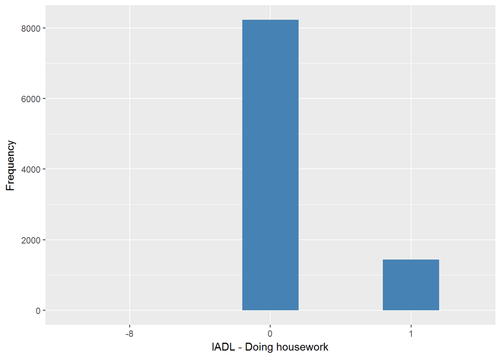

#### 2.1.7.2 Harmonisation algorithm

To compute the harmonize variable from the study-specific variable it has to be recoded as follows:

- `1 into 0`
- `0 into 1`
- `-8 Don't know into 998`

**R script:**

```r
ELSA_ds_w7 <- tibble(id = ELSA_w7_iadl_housewk$id)
ELSA_ds_w7$iadl_housewk <- car::recode(ELSA_w7_iadl_housewk$headlho, "0 = '1';1 = '0';-9 = '997';-8 = '998';-1 = '996' ")
ELSA_ds_w7$iadl_housewk <- labelled(ELSA_ds_w7$iadl_housewk, labels = c(Yes = 0,
    No = 1, Missing = 999, Do_not_know = 998, Refuse = 997, Not_applicable = 996,
    Does_not_answer = 995, Not_attempt_not_done = 994, Disable_to_measure = 993,
    Impute = 992, CAPI_interviewer_error = 991))
```

#### 2.1.7.3 Statistical description of the new harmonised variable

| Sample size | Missing values |
| --- | --- |
| 9666 | 2 |

Category

|  | 0 | 1 |
| --- | --- | --- |
| Frequency | 1435.00 | 8229.00 |
| Percentage | 14.85 | 85.13 |

Type of missing

|  | 991 | 992 | 993 | 994 | 995 | 996 | 997 | 998 | 999 | NA |
| --- | --- | --- | --- | --- | --- | --- | --- | --- | --- | --- |
| Frequency | 0 | 0 | 0 | 0 | 0 | 0 | 0 | 2.00 | 0 | 0 |
| Percentage | 0 | 0 | 0 | 0 | 0 | 0 | 0 | 0.02 | 0 | 0 |

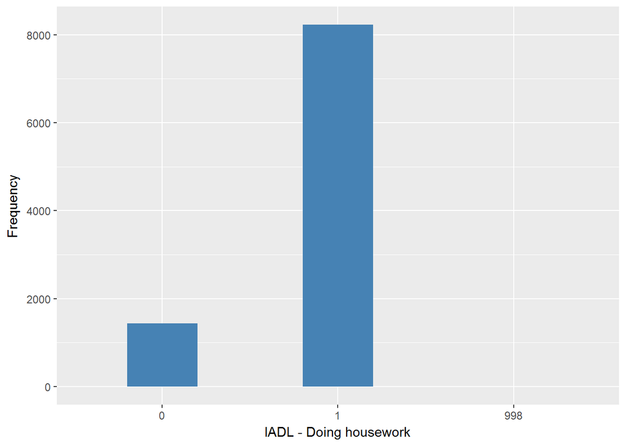

#### 2.1.7.4 Validation

|  | 1->0 | 0->1 | -8->998 |
| --- | --- | --- | --- |
| BeforeH | 1435 | 8229 | 2 |
| AfterH | 1435 | 8229 | 2 |

### 2.1.8 Summary of descriptive statistics of the harmonised variable accross populations and waves

Two tables are generated:

1. Percentages of categories in each harmonised variable.
2. Frequencies and percentages of individuals with different trajectories. To avoid too large table, Only trajectories with percentages larger than 0.3 are shown.

| val | label | w1 | w2 | w3 | w4 | w5 | w6 | w7 |
| --- | --- | --- | --- | --- | --- | --- | --- | --- |
| 0 | Presence | 15.53 | 16.91 | 15.1 | 14.57 | 15.64 | 15.14 | 14.85 |
| 1 | Absence | 82.89 | 83.06 | 84.86 | 85.35 | 84.28 | 84.81 | 85.13 |
| 991 | CAPI_interviewer_error | 0 | 0 | 0 | 0 | 0 | 0 | 0 |
| 992 | Impute | 0 | 0 | 0 | 0 | 0 | 0 | 0 |
| 993 | Disable_to_measure | 0 | 0 | 0 | 0 | 0 | 0 | 0 |
| 994 | Not_attempt_not_done | 0 | 0 | 0 | 0 | 0 | 0 | 0 |
| 995 | Does_not_answer | 0 | 0 | 0 | 0 | 0 | 0 | 0 |
| 996 | Not_applicable | 1.45 | 0 | 0.04 | 0 | 0 | 0 | 0 |
| 997 | Refuse | 0.03 | 0.02 | 0 | 0.06 | 0.05 | 0.03 | 0 |
| 998 | Do_not_know | 0.1 | 0.01 | 0 | 0.02 | 0.03 | 0.02 | 0.02 |
| 999 | Missing | 0 | 0 | 0 | 0 | 0 | 0 | 0 |
| NA | NA | 0 | 0 | 0 | 0 | 0 | 0 | 0 |
| n | sample size | 12099 | 9432 | 9771 | 11050 | 10274 | 10601 | 9666 |

[output not shown]

No comments